# Case Study: Quality Prediction In Mining Process

[figure not shown]

# Introduction

In this project, machine learning and deep learning models will be train to predict the percentage of Silica Concentrate in the Iron ore concentrate per minute. This project could be practically used in Mining Industry to get the percentage of Silica Concentrate at a much faster rate compared to the traditional methods.

Freeport-McMoran is one of the largest mining companies in U.S.. They have made use of custom built AI model to boost the output in their mining facilities.

The 4th Industrial Revolution: How Mining Companies Are Using AI, Machine Learning And Robots:

- https://www.forbes.com/sites/bernardmarr/2018/09/07/the-4th-industrial-revolution-how-mining-companies-are-using-ai-machine-learning-and-robots/#fcde6c6497e5

**Problem:**

- Although the percentage of Silica is measured, its a lab measurement, which means that it takes at least one hour for the process engineers to have this value. So if it is posible to predict the amount of impurity in the process
- Pedict the percentage of Silica Concentrate in the Iron ore concentrate per minute.

**Dataset:**

- By leveraging past 3+ data, AI can help the mining facility sustain a faster production pace with no loss efficiency. Efficiency can be improve by performing operational tweaks to boost output. (Ex. Copper production could be increase if mili was fed with more ore per minute.)

**Source:** Kaggle Competition

# Review

[figure not shown]

# Libraries And Data Importation

```python
# Import libraries
import pandas as pd
import numpy as np
import seaborn as sns
import matplotlib.pyplot as plt
import zipfile
```

```python
# Import data
mining_df = pd.read_csv('mining_data.csv')
```

# Data Exploraton

```python
# Check data
mining_df.head()
```

|  | % Iron Feed | % Silica Feed | Starch Flow | Amina Flow | Ore Pulp Flow | Ore Pulp pH | Ore Pulp Density | Flotation Column 01 Air Flow | Flotation Column 02 Air Flow | Flotation Column 03 Air Flow | ... | Flotation Column 07 Air Flow | Flotation Column 01 Level | Flotation Column 02 Level | Flotation Column 03 Level | Flotation Column 04 Level | Flotation Column 05 Level | Flotation Column 06 Level | Flotation Column 07 Level | % Iron Concentrate | % Silica Concentrate |
| --- | --- | --- | --- | --- | --- | --- | --- | --- | --- | --- | --- | --- | --- | --- | --- | --- | --- | --- | --- | --- | --- |
| 0 | 55.2 | 16.98 | 3196.680000 | 542.694333 | 396.284000 | 10.158367 | 1.668070 | 249.796333 | 250.275667 | 248.668000 | ... | 250.547000 | 464.978667 | 490.450333 | 443.465000 | 442.856333 | 438.782333 | 452.248333 | 466.300667 | 67.06 | 1.11 |
| 1 | 55.2 | 16.98 | 3213.673333 | 540.649333 | 397.949333 | 10.156600 | 1.664973 | 249.536000 | 250.752000 | 250.968333 | ... | 249.807000 | 445.001000 | 362.894667 | 442.748333 | 471.045333 | 445.239667 | 443.630667 | 426.921667 | 67.06 | 1.11 |
| 2 | 55.2 | 16.98 | 3180.080000 | 535.929333 | 397.305000 | 10.154800 | 1.661877 | 249.576000 | 250.279667 | 251.001333 | ... | 249.686667 | 443.574667 | 478.916333 | 432.779333 | 437.401667 | 441.761000 | 490.824667 | 478.046667 | 67.06 | 1.11 |
| 3 | 55.2 | 16.98 | 3196.713333 | 535.102000 | 397.010667 | 10.153067 | 1.658780 | 249.380333 | 248.799333 | 250.241333 | ... | 249.926333 | 440.731333 | 488.994000 | 452.461333 | 439.572667 | 434.027333 | 457.083667 | 458.815667 | 67.06 | 1.11 |
| 4 | 55.2 | 16.98 | 3111.723333 | 532.735000 | 395.263667 | 10.151300 | 1.655680 | 249.426667 | 252.209667 | 249.243333 | ... | 249.975667 | 445.851667 | 418.860000 | 462.936667 | 454.948333 | 453.571667 | 446.831667 | 426.600000 | 67.06 | 1.11 |

5 rows × 23 columns

```python
# Check data statistics
mining_df.describe()
```

|  | % Iron Feed | % Silica Feed | Starch Flow | Amina Flow | Ore Pulp Flow | Ore Pulp pH | Ore Pulp Density | Flotation Column 01 Air Flow | Flotation Column 02 Air Flow | Flotation Column 03 Air Flow | ... | Flotation Column 07 Air Flow | Flotation Column 01 Level | Flotation Column 02 Level | Flotation Column 03 Level | Flotation Column 04 Level | Flotation Column 05 Level | Flotation Column 06 Level | Flotation Column 07 Level | % Iron Concentrate | % Silica Concentrate |
| --- | --- | --- | --- | --- | --- | --- | --- | --- | --- | --- | --- | --- | --- | --- | --- | --- | --- | --- | --- | --- | --- |
| count | 245700.000000 | 245700.000000 | 245700.000000 | 245700.000000 | 245700.000000 | 245700.000000 | 245700.000000 | 245700.000000 | 245700.000000 | 245700.000000 | ... | 245700.000000 | 245700.000000 | 245700.000000 | 245700.000000 | 245700.000000 | 245700.000000 | 245700.000000 | 245700.000000 | 245700.000000 | 245700.000000 |
| mean | 56.294974 | 14.651438 | 2869.241181 | 488.144186 | 397.577332 | 9.767534 | 1.680348 | 280.166032 | 277.172893 | 281.097236 | ... | 290.774336 | 520.242050 | 522.648563 | 531.355055 | 420.306805 | 425.237994 | 429.927646 | 421.006767 | 65.049435 | 2.327228 |
| std | 5.158958 | 6.808961 | 1187.990184 | 90.736360 | 9.468496 | 0.387036 | 0.069213 | 29.616570 | 29.936823 | 28.537193 | ... | 28.158596 | 130.389539 | 127.450562 | 150.614529 | 90.566437 | 83.601851 | 85.320602 | 83.736727 | 1.118479 | 1.125623 |
| min | 42.740000 | 1.310000 | 0.074147 | 241.699632 | 376.272600 | 8.753370 | 1.519829 | 175.666333 | 175.923177 | 176.471917 | ... | 186.074077 | 149.451600 | 211.266111 | 126.352031 | 162.293185 | 167.139620 | 161.485667 | 175.908240 | 62.050000 | 0.600000 |
| 25% | 52.670000 | 8.940000 | 2073.322500 | 432.204667 | 395.212583 | 9.527157 | 1.647197 | 250.268667 | 250.367333 | 250.693667 | ... | 263.524333 | 413.516320 | 442.291000 | 410.134583 | 356.440167 | 357.074583 | 358.078583 | 356.567833 | 64.370000 | 1.440000 |
| 50% | 56.080000 | 13.850000 | 2994.311667 | 504.510667 | 399.354833 | 9.797963 | 1.697560 | 299.418000 | 297.433000 | 299.048333 | ... | 299.350833 | 492.971167 | 496.380667 | 494.859500 | 410.511667 | 408.022833 | 419.931167 | 410.043333 | 65.210000 | 2.000000 |
| 75% | 59.720000 | 19.600000 | 3712.951667 | 553.479083 | 402.458750 | 10.037833 | 1.728257 | 300.127333 | 300.435000 | 300.308667 | ... | 301.239667 | 594.960083 | 595.989167 | 601.060000 | 486.533417 | 485.580833 | 490.725500 | 475.922283 | 65.860000 | 3.010000 |
| max | 65.780000 | 33.400000 | 6295.130657 | 739.422405 | 418.625439 | 10.808046 | 1.853229 | 372.387588 | 369.550000 | 359.948635 | ... | 370.190800 | 862.197932 | 828.593000 | 886.820204 | 680.019967 | 675.571459 | 698.621871 | 659.618696 | 68.010000 | 5.530000 |

8 rows × 23 columns

```python
# Check data types
mining_df.dtypes
```

```
% Iron Feed                     float64
% Silica Feed                   float64
Starch Flow                     float64
Amina Flow                      float64
Ore Pulp Flow                   float64
Ore Pulp pH                     float64
Ore Pulp Density                float64
Flotation Column 01 Air Flow    float64
Flotation Column 02 Air Flow    float64
Flotation Column 03 Air Flow    float64
Flotation Column 04 Air Flow    float64
Flotation Column 05 Air Flow    float64
Flotation Column 06 Air Flow    float64
Flotation Column 07 Air Flow    float64
Flotation Column 01 Level       float64
Flotation Column 02 Level       float64
Flotation Column 03 Level       float64
Flotation Column 04 Level       float64
Flotation Column 05 Level       float64
Flotation Column 06 Level       float64
Flotation Column 07 Level       float64
% Iron Concentrate              float64
% Silica Concentrate            float64
dtype: object
```

```python
# Check for missing values
mining_df.isnull().mean()
```

```
% Iron Feed                     0.0
% Silica Feed                   0.0
Starch Flow                     0.0
Amina Flow                      0.0
Ore Pulp Flow                   0.0
Ore Pulp pH                     0.0
Ore Pulp Density                0.0
Flotation Column 01 Air Flow    0.0
Flotation Column 02 Air Flow    0.0
Flotation Column 03 Air Flow    0.0
Flotation Column 04 Air Flow    0.0
Flotation Column 05 Air Flow    0.0
Flotation Column 06 Air Flow    0.0
Flotation Column 07 Air Flow    0.0
Flotation Column 01 Level       0.0
Flotation Column 02 Level       0.0
Flotation Column 03 Level       0.0
Flotation Column 04 Level       0.0
Flotation Column 05 Level       0.0
Flotation Column 06 Level       0.0
Flotation Column 07 Level       0.0
% Iron Concentrate              0.0
% Silica Concentrate            0.0
dtype: float64
```

# Data Visualization

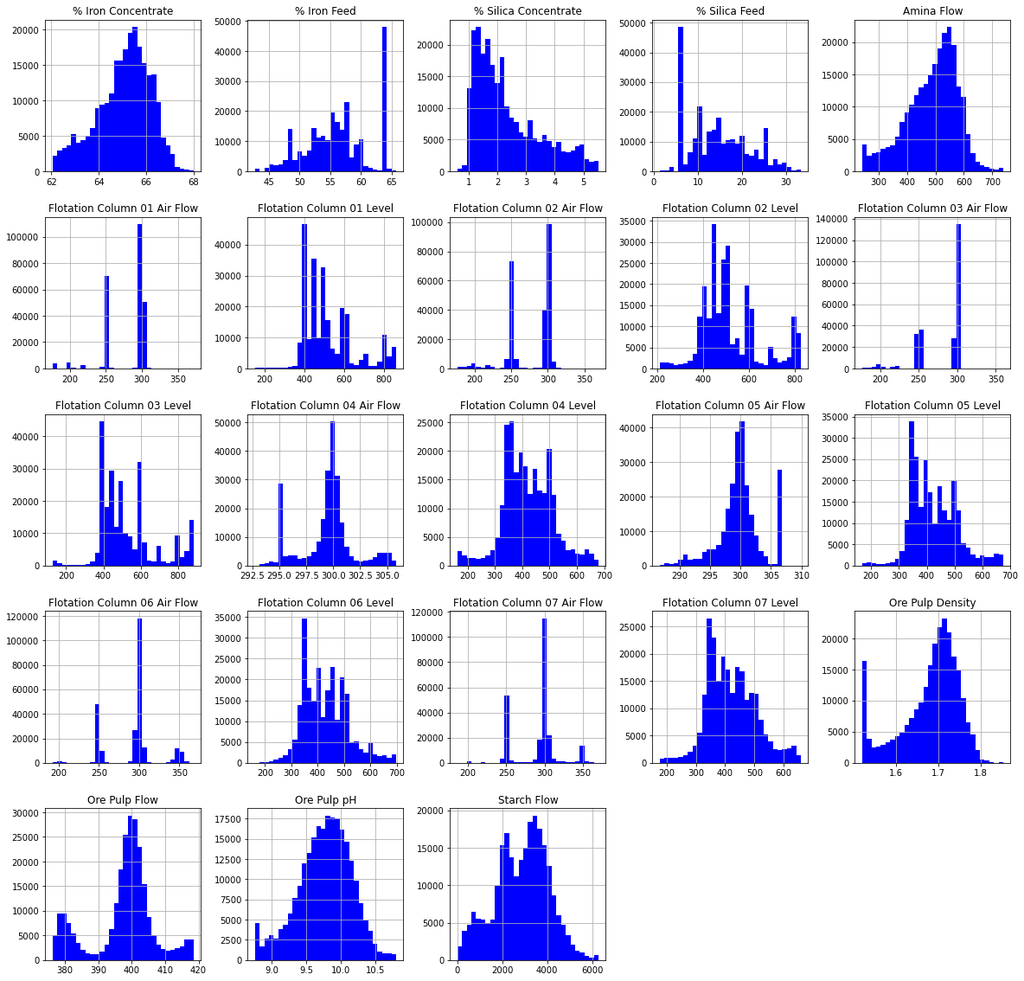

```python
# Create bar chart
mining_df.hist(bins = 30, figsize = (20,20), color = 'b')
plt.show()
```

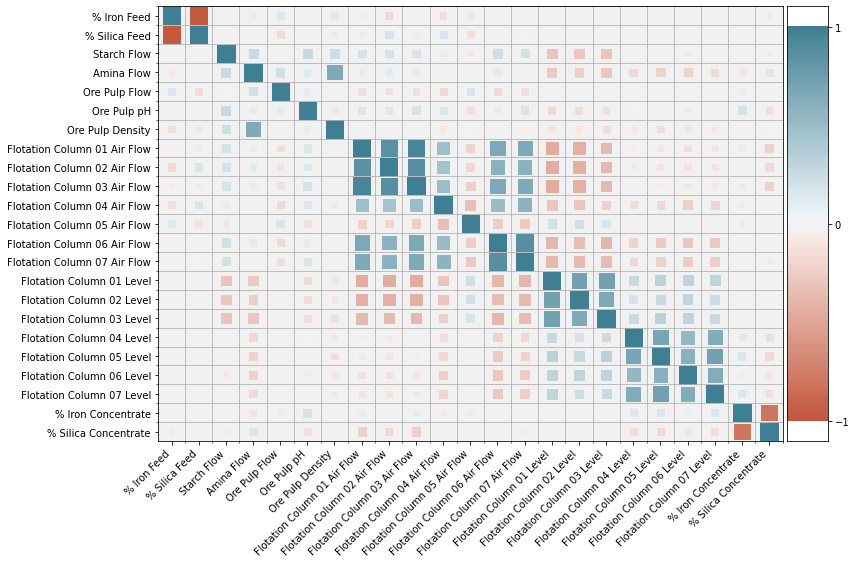

```python
# Import library
from heatmap import corrplot

# Show correlation in the features by using heatmap
plt.figure(figsize=(12, 8))
corrplot(mining_df.corr(), size_scale=300)
```

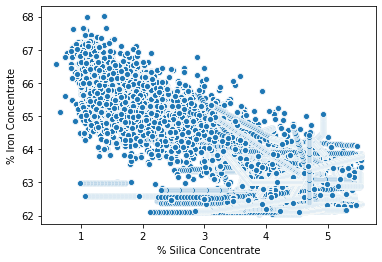

```python
# Create scatterplot
sns.scatterplot(mining_df['% Silica Concentrate'], mining_df['% Iron Concentrate'])
plt.show()
```

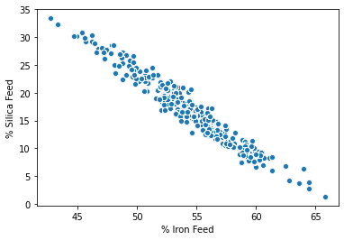

```python
# Create scatterplot
sns.scatterplot(mining_df['% Iron Feed'], mining_df['% Silica Feed'])
plt.show()
```

# Data Preprocessing

```python
# Label Independent variables
df_iron = mining_df.drop(columns = '% Silica Concentrate')

# Label dependent variables
df_iron_target = mining_df['% Silica Concentrate']
```

```python
# Check Independent variables shape
df_iron.shape
```

```
(245700, 22)
```

```python
# Check dependent variables shape
df_iron_target.shape
```

```
(245700,)
```

```python
# Transform into array
df_iron = np.array(df_iron)

# Transform into array
df_iron_target = np.array(df_iron_target)
```

```python
# Reshaping the array
df_iron_target = df_iron_target.reshape(-1,1)

# Check dimension
df_iron_target.shape
```

```
(245700, 1)
```

```python
# Import library
from sklearn.preprocessing import StandardScaler, MinMaxScaler

# Scale the independent variables
scaler_x = StandardScaler()
X = scaler_x.fit_transform(df_iron)


# Scale the dependent variables
scaler_y = StandardScaler()
y = scaler_y.fit_transform(df_iron_target)
```

```python
# Import libraru
from sklearn.model_selection import train_test_split

# Split the data
X_train, X_test, y_train, y_test = train_test_split(X, y, test_size = 0.2, random_state = 0)
```

```python
# Check train dataset shape
X_train.shape, y_train.shape
```

```
((196560, 22), (196560, 1))
```

```python
# Check train dataset shape
X_test.shape, y_test.shape
```

```
((49140, 22), (49140, 1))
```

# Model Training And Evaluation

## Linear Regression Model

```python
# Import libraries
from sklearn.linear_model import LinearRegression
from sklearn.metrics import mean_squared_error, accuracy_score

# Train the model
LinearRegression_model = LinearRegression()
LinearRegression_model.fit(X_train, y_train)
```

```
LinearRegression()
```

```python
# Check Linear Regression model accuracy
accuracy_LinearRegression = LinearRegression_model.score(X_test, y_test)
accuracy_LinearRegression
```

```
0.6817924522132923
```

## Decision Tree Regressor Model

```python
# Import lirbary
from sklearn.tree import DecisionTreeRegressor

# Train the model
DecisionTree_model = DecisionTreeRegressor()
DecisionTree_model.fit(X_train, y_train)
```

```
DecisionTreeRegressor()
```

```python
# Check Decision Tree model accuracy
accuracy_DecisionTree = DecisionTree_model.score(X_test, y_test)
accuracy_DecisionTree
```

```
0.9827050277688161
```

## XGBoost Regressor Model

```python
# Import library
from xgboost import XGBRegressor

# Train the model
xgb = XGBRegressor()
xgb.fit(X_train, y_train)
```

```
XGBRegressor(base_score=0.5, booster='gbtree', colsample_bylevel=1,
             colsample_bynode=1, colsample_bytree=1, gamma=0, gpu_id=-1,
             importance_type='gain', interaction_constraints='',
             learning_rate=0.300000012, max_delta_step=0, max_depth=6,
             min_child_weight=1, missing=nan, monotone_constraints='()',
             n_estimators=100, n_jobs=0, num_parallel_tree=1, random_state=0,
             reg_alpha=0, reg_lambda=1, scale_pos_weight=1, subsample=1,
             tree_method='exact', validate_parameters=1, verbosity=None)
```

```python
# Check XGBoost model accuracy
xgb.score(X_test, y_test)
```

```
0.9346029693675422
```

## Artificial Neural Network Model

```python
# Import library
import tensorflow as tf
from tensorflow import keras
from tensorflow.keras.layers import Dense, Activation, Dropout
from tensorflow.keras.optimizers import Adam

# Create model architecture
optimizer = Adam(learning_rate=0.001, beta_1 = 0.9, beta_2 = 0.999, epsilon = 1e-07, amsgrad = False)
ANN_model = keras.Sequential()
ANN_model.add(Dense(250, input_dim = 22, kernel_initializer='normal',activation='relu'))
ANN_model.add(Dense(500,activation = 'relu'))
ANN_model.add(Dropout(0.1))
ANN_model.add(Dense(1000, activation = 'relu'))
ANN_model.add(Dropout(0.1))
ANN_model.add(Dense(1000, activation = 'relu'))
ANN_model.add(Dropout(0.1))
ANN_model.add(Dense(500, activation = 'relu'))
ANN_model.add(Dropout(0.1))
ANN_model.add(Dense(250, activation = 'relu'))
ANN_model.add(Dropout(0.1))
ANN_model.add(Dense(1, activation = 'linear'))

# Compile the model
ANN_model.compile(loss = 'mse', optimizer = 'adam')

# Check modelsummary
ANN_model.summary()
```

```
Model: "sequential"
_________________________________________________________________
Layer (type)                 Output Shape              Param #
=================================================================
dense (Dense)                (None, 250)               5750
_________________________________________________________________
dense_1 (Dense)              (None, 500)               125500
_________________________________________________________________
dropout (Dropout)            (None, 500)               0
_________________________________________________________________
dense_2 (Dense)              (None, 1000)              501000
_________________________________________________________________
dropout_1 (Dropout)          (None, 1000)              0
_________________________________________________________________
dense_3 (Dense)              (None, 1000)              1001000
_________________________________________________________________
dropout_2 (Dropout)          (None, 1000)              0
_________________________________________________________________
dense_4 (Dense)              (None, 500)               500500
_________________________________________________________________
dropout_3 (Dropout)          (None, 500)               0
_________________________________________________________________
dense_5 (Dense)              (None, 250)               125250
_________________________________________________________________
dropout_4 (Dropout)          (None, 250)               0
_________________________________________________________________
dense_6 (Dense)              (None, 1)                 251
=================================================================
Total params: 2,259,251
Trainable params: 2,259,251
Non-trainable params: 0
_________________________________________________________________
```

```python
# Initiate model training
history = ANN_model.fit(X_train, y_train, epochs = 5, validation_split = 0.2)
```

```python
# Evaluate the ANN model
result = ANN_model.evaluate(X_test, y_test)
accuracy_ANN = 1 - result
print("Accuracy : {}".format(accuracy_ANN))
```

```
Accuracy : 0.9248149991035461
```

# Calculate Regression KPIs

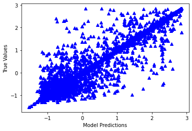

```python
# From the above results, it can be seen that, decision tree model out-performs the other models.

# Plot True values and Model Predictions
y_predict = DecisionTree_model.predict(X_test)
plt.plot(y_predict, y_test, '^', color = 'b')
plt.xlabel('Model Predictions')
plt.ylabel('True Values')
plt.show()
```

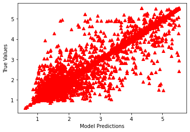

```python
# Plot True values and Model Predictions with their proper range
y_predict_orig = scaler_y.inverse_transform(y_predict)
y_test_orig = scaler_y.inverse_transform(y_test)
plt.plot(y_test_orig, y_predict_orig, "^", color = 'r')
plt.xlabel('Model Predictions')
plt.ylabel('True Values')
plt.show()
```

```python
# Import libraries
from sklearn.metrics import r2_score, mean_squared_error, mean_absolute_error
from math import sqrt

# Check evaluation metrics
k = X_test.shape[1]
n = len(X_test)
RMSE = float(format(np.sqrt(mean_squared_error(y_test_orig, y_predict_orig)),'.3f'))
MSE = mean_squared_error(y_test_orig, y_predict_orig)
MAE = mean_absolute_error(y_test_orig, y_predict_orig)
r2 = r2_score(y_test_orig, y_predict_orig)
adj_r2 = 1-(1-r2)*(n-1)/(n-k-1)

print('RMSE =',RMSE, '\nMSE =',MSE, '\nMAE =',MAE, '\nR2 =', r2, '\nAdjusted R2 =', adj_r2)
```

```
RMSE = 0.148
MSE = 0.02202306497665563
MAE = 0.022432923934771264
R2 = 0.9827050277688161
Adjusted R2 = 0.9826972811762089
```

# Conclusion

The Decision Tree Model was able to obtained a 98% accuracy in prediction and also outperforms an ANN model. Although the ANN model was only trained in five iterations and can bu further improve by adding more layers, it will still take a lot of time to train and consume a lot of computing power as well. Due to the good scores in evaluation metrics the model can be deploy into the production to save process engineers a lot of time in their workload.